# Mortality: Investigating death trends in South Africa

Ahmad Soni - 668564 Simon Rosen - 1391995 Nasiem Ayob - 1825850

## Introduction

Mortality statistics in general are a valuable resource in gauging Healthcare in a country and the challenges the Healthcare system may be facing. By analysing Mortality data we can gain a better idea of how a country can deal with possible pandemics and pinpoint specific areas of concern. By analysing mortality data we can further understand our healthcare system and the problems it faces. This can give both us and government organizations a better idea on how to better improve the healthcare system in South Africa.

We believe there is a lot to be gained by analysing this data, and such we have decided to focus on this for our mini project.

**The specific questions we wish to address are the following:**

1. Is there a relationship between month of death to age, gender or race?

We wish to investigate if there are more people of different ages, genders and race passing away more frequently during specific months

1. Does the geographical type of people influence the type of death? For example, do people in different provinces suffer from natural deaths more frequently.

We wish to investigate if there are more deaths in particular sections of the country as it might be a good indicator of where major problem areas lie.

1. Do demographic features population group(race) and sex influence cause of death?

We wish to investigate if certain demographic groups are experiencing more death than others as it might give us a better understanding if certain demographic groups need to be focused for healthcare interventions.

**There are limitations present in the dataset which we will have to accomodate for, these being:**

We don't have exact numbers for the total population groups in the geographical types so we will have to make some assumptions in that section

There is no available data passed 2011 for the exact statistics we are looking for so some of the information may have been subject to change, especially with recent pandemics. The main reason for this is organizing a country-wide survey is inredibly time consuming and resource heavy, detailed below in data description. Due to this it can only realistically be carried out between large year gaps.

We are also using a 10% sample of the original data so there might be small innacuracies but nothing that should affect our overall results. Another issue regarding this is that the original dataset is too large for any of our computers to generate models on, therefore we have to use the 10% sample.

We did want to extend our dataset originally but ran into issues with the website we retrieved the data from initially having network issues.

### Methodology

A short summary of the methodology is as follows:

In the data description section, we will look at where the data was gathered and how. We will also investigate important aspects of the data relating to its contents, validity and quality. By using these aspects, we will be able to formulate a good idea about whether the questions we have asked can be answered by the data we have been given. Our next problem would be to load the data into Pandas and manipulate it into useable formats. This is done by cleaning empty values, isolating and grouping related categories and renaming certain categories to make them easier to understand. Once the data has been cleaned and organized, we are ready to start performing some basic exploratory analyses. These will consist of basic plots which show some simple relationships for the sake of better understanding our data and for comparison to other datasets to ensure validity.

The more indepth methodology will be handled by the next few sections. We will generate and fit machine learning models onto our research questions so we can predict answers to them. We will also generate and apply appropriate hypothesis to our research questions. This will allow us to better answer them, specifically with regards to ascertaining relationships between variables.

Finally we will interpret and discuss our results and finish off with future research in this area.

### Contents of this notebook

**1. Introduction**

A brief introduction and overview of this Notebook

**2. Data Description**

A overview on the data that is being used as well as methodology

**3. Data Wrangling**

Manipulation of the data into more useable formats

**4. Exploratory Analyses**

Initial Plots and explorations into the dataset

**5. Model Fitting**

Generate and fit models for our research questions

**6. Hypothesis Testing**

Generate Hypothesis tests for each researc question

**7. Interpretation of Results**

Interpretation of our models and hypothesis tests

**8. Conclusion**

Answers and Further research

## Data Description

The data we have decided to use is a 10% sample of the South African 2011 Mortality Consensus. It was gathered by download from http://nesstar.statssa.gov.za:8282/webview/ on the 9th of March 2021.

The data is comprised of 40303 entries (rows) and 12 categories (columns)

The data for the South African 2011 Census was gathered through a rigourus survey scheme. The process involved a deep planning and testing phase where the act of gathering survey data was ensured to be as accurate and efficient as possible. The planning process started in 2003 and the first pilots were tested in 2008 and 2009. The final and largest test was performed in 2010. The final survey process started on the 9th of October 2011 and involved a team of field staff of over 160 000 individuals. The surveys yielded 15 million questionnaires relating to different aspects of society in South Africa. These questionnaires then needed to be processed and captured digitally. This data was then passed on to a data editing team who compiled, formatted and split it into the useable formats we find on the StatsSA webpage. We have chosen the mortality subset of the giant overall Census dataset. Sadly, mortality was the final entry on the census questionnaire and it was reported that by this stage, there were many blank responses present, signifying some form of respondent fatigue. There also seemed to be a general trend of people not wanting to answer questions related to mortality based on the negative nature of the questions. This explains our number of entries compared to the number of surveys that were collected. All data was collated and split into seperate frames which were named Enumeration Areas or EAs.

The 10% sample was selected by selecting only data where all EA's were complete. There was also a restriction placed where all EA's had to have well defined boundaries in the selection sample, and these boundaries should correspond to the boundaries on the initial complete dataset. This allows accurate estimates to be made in relation to the complete dataset.

### Contents

Contained within is mortality data relating to:

- Age `M04_AGE`
- Sex `M03_SEX`
- Region
  - Province `M_PROVINCE`
  - District `M_DISTRICT`
  - Muncipality `M_MUNIC`)
- Geographical type `M_GEOTYPE`
- Date of death, month `M02_MONTH` and year `M02_YEAR`
- Death type, unnatural or natural `M05_CAUSE`
- Population group (race) `M_MX_POP_GROUP`

Since this is an official data publication, the attached PDF for the data shows it has been validated by the South African Government.

### Validations

In order to validate our data, we need to compare it to similar mortality data from other countries and compare key statistics. The total number of deaths recorded in South Africa in 2011 was 604545 comparing this to the total deaths in the United States in 2011, who had a total of 2515458. If we consider the US population to be 6 times that of South Africa, we get numbers within an acceptable range for total deaths.

If we compare the total population the entire consensus covered between the 2011, 2007 and 2001 Census data in South Africa, we have population numbers of 51 770 560 , 48 502 059 and 44 819 778 repectively. Which makes sense since we have a positive population growth. This further validates the 2011 data.

### Data Quality

Accuracy: Due to the stringent collection process detailed above, all data contained has been gathered appropriately and is approved by Statistics South Africa, the leading statistics gathering instituition in the country.

Reliability: The statistics we have contain multiple entries under all categories showing its reliability.

Relevancy: All of the data contained is significant and useful to the purpose of evaluating mortality.

Validity: Each data entry conforms to the same format presented throughout the dataset.

### Relavancy of 10% sample

The data contains mortality data per month, geographical location, age and gender. This should allow us to answer the questions we have proposed in our introduction. The data is representative of the larger complete dataset. The way the 10% sample was selected means we shoud still have accurate results enough to infer conclusions and relationships from. We opted to use the 10% sample as it would give us similar or the same results and the amount of data compared to the full dataset is much easier to use and manipulate.

The size of the full dataset also produced a technical limitation as none of our members have computing power powerful enough to generate models on a dataset that large.

## Data Wrangling

```python
import matplotlib.pyplot as plt
import seaborn as sns
import pandas as pd
import numpy as np
import pickle
from matplotlib import pyplot as plt
import sys
if not sys.warnoptions:
    import warnings
    warnings.simplefilter("ignore")
    #simplefilter(action='ignore', category=FutureWarning)




sns.set()

from pandas.api.types import CategoricalDtype
```

```python
df = pd.read_csv("data/2011_census_mortality.csv", index_col="SN")
```

## Preliminary & Cursory Audit of Data

```python
df.head()
```

| SN | M02_MONTH | M02_YEAR | M03_SEX | M04_AGE | M05_CAUSE | M_MX_POP_GROUP | M_GEOTYPE | M_PROVINCE | M_DISTRICT | M_MUNIC | MORTALITY_10PERCENT_WEIGHT |
| --- | --- | --- | --- | --- | --- | --- | --- | --- | --- | --- | --- |
| 11809257867 | 3 | 2011 | 2 | 0 | 1 | 2.0 | 3 | 1 | 101 | 160 | 28.748530 |
| 11916034982 | 10 | 2011 | 1 | 25 | 9 | 1.0 | 1 | 1 | 101 | 160 | 11.461345 |
| 10104528209 | 8 | 2011 | 1 | 85 | 1 | 2.0 | 1 | 1 | 101 | 160 | 10.559567 |
| 10104521225 | 5 | 2011 | 1 | 72 | 1 | 2.0 | 1 | 1 | 101 | 160 | 11.653297 |
| 11917226239 | 9 | 2011 | 1 | 73 | 1 | 2.0 | 1 | 1 | 101 | 160 | 11.653297 |

```python
df.info()
```

```
<class 'pandas.core.frame.DataFrame'>
Int64Index: 40303 entries, 11809257867 to 11407403066
Data columns (total 11 columns):
 #   Column                      Non-Null Count  Dtype
---  ------                      --------------  -----
 0   M02_MONTH                   40303 non-null  int64
 1   M02_YEAR                    40303 non-null  int64
 2   M03_SEX                     40303 non-null  int64
 3   M04_AGE                     40303 non-null  int64
 4   M05_CAUSE                   40303 non-null  int64
 5   M_MX_POP_GROUP              40288 non-null  float64
 6   M_GEOTYPE                   40303 non-null  int64
 7   M_PROVINCE                  40303 non-null  int64
 8   M_DISTRICT                  40303 non-null  int64
 9   M_MUNIC                     40303 non-null  int64
 10  MORTALITY_10PERCENT_WEIGHT  40303 non-null  float64
dtypes: float64(2), int64(9)
memory usage: 3.7 MB
```

From the above we can see that all the columns are numerical even though the majority of them should be categorical. Given with the data from StatsSA was also a PDF that for each column explained which categorical value each numerical value represented. Using this we will later map the numerical values to string values then to categorical values.

**Number of NaN values for each column:**

```python
df.isna().sum()
```

```
M02_MONTH                      0
M02_YEAR                       0
M03_SEX                        0
M04_AGE                        0
M05_CAUSE                      0
M_MX_POP_GROUP                15
M_GEOTYPE                      0
M_PROVINCE                     0
M_DISTRICT                     0
M_MUNIC                        0
MORTALITY_10PERCENT_WEIGHT     0
dtype: int64
```

From the above we can see that there are very minimal missing values, but this is not actually the case as well see later that dummy variables are used to represent missing data.

Since this is a survey and not a census, this data is only a sample of the population. In this case the data only makes up 10% of the deaths that occurred in 2011. Thankfully, the data accounts for this with the introduction of a sample weight which is a value that aims to account for the selection of specific observations with inherent bias such as from non-responses, non-coverage, or oversampling. Using this sample weight in our statistics will give us a more accurate representation of the statistics of the population rather than just this sample.

### Rename Columns to be more usable

The names of these columns are rather unwieldy to work with so we will rename them to be easier to work with while still retaining their meaning.

```python
df.columns
```

```
Index(['M02_MONTH', 'M02_YEAR', 'M03_SEX', 'M04_AGE', 'M05_CAUSE',
       'M_MX_POP_GROUP', 'M_GEOTYPE', 'M_PROVINCE', 'M_DISTRICT', 'M_MUNIC',
       'MORTALITY_10PERCENT_WEIGHT'],
      dtype='object')
```

Missing values:

```python
rename_dict = {
    'M02_MONTH': 'month',
    'M02_YEAR': 'year',
    'M03_SEX': 'sex',
    'M04_AGE': 'age',
    'M05_CAUSE': 'cause',
    'M_MX_POP_GROUP': 'pop_group',
    'M_GEOTYPE': 'geotype',
    'M_PROVINCE': 'province',
    'M_DISTRICT': 'district',
    'M_MUNIC': 'munic',
    'MORTALITY_10PERCENT_WEIGHT': 'sample_weight'
}
df.rename(rename_dict, axis=1, inplace=True)
df.columns
```

```
Index(['month', 'year', 'sex', 'age', 'cause', 'pop_group', 'geotype',
       'province', 'district', 'munic', 'sample_weight'],
      dtype='object')
```

```python
clean_df = df.copy()
```

## Convert Columns to Correct Format

As explained above some of the columns are represented by numerical values rather than categorical so we will now remedy that. In the data dummy variables are used to represent NaN values so we will replace these dummy variables with np.nan for ease of use later.

### Month

```python
clean_df['month'].value_counts()
```

```
10    5443
9     3919
6     3816
12    3410
7     3375
8     3291
11    3220
4     2908
5     2872
3     2858
2     2644
1     2547
Name: month, dtype: int64
```

While month could be represented as a categorical value, it is easier to use later on when kept as numerical thus we will not change it.

### Year

```python
clean_df['year'].value_counts()
```

```
2011    30560
2010     9743
Name: year, dtype: int64
```

This data also includes samples for 2010 in addition to for 2011.

### Date

Having the month and year stored as a single value can be useful for later analysis so we will combine these two into a single PeriodArray object with the frequency set as months. This object is similar to datetime except that it has a lower granularity – in this case it does not include days.

```python
clean_df['date'] = clean_df['month'].astype(str) + "-" + clean_df['year'].astype(str)
clean_df['date'] = pd.to_datetime(clean_df['date'], format="%m-%Y")
clean_df['date'] = clean_df['date'].dt.to_period('M')
clean_df[['date']].info()
```

```
<class 'pandas.core.frame.DataFrame'>
Int64Index: 40303 entries, 11809257867 to 11407403066
Data columns (total 1 columns):
 #   Column  Non-Null Count  Dtype
---  ------  --------------  -----
 0   date    40303 non-null  period[M]
dtypes: period[M](1)
memory usage: 629.7 KB
```

### Sex

Sex is represented numerically with dummy variables representing each category or NaN. Thus, we will convert it to the correct categorical format.

Mapping:

| Numerical Value | Categorical Value |
| --- | --- |
| 1 | male |
| 2 | female |
| 9 | nan |

```python
df['sex'].value_counts()
```

```
1    20909
2    19240
9      154
Name: sex, dtype: int64
```

```python
sex_map = {
    1:"male",
    2:"female",
    9: np.NaN # 'Unspecified'
}
clean_df['sex'] = df['sex'].map(sex_map)
clean_df['sex'] = clean_df['sex'].astype("category")
clean_df['sex'].value_counts()
```

```
male      20909
female    19240
Name: sex, dtype: int64
```

No of NaN values:

```python
clean_df['sex'].isna().sum()
```

```
154
```

We can see that for `sex` missing values are indeed present.

### Age

Age is correctly represented as integer so we do not need to change its format.

```python
df['age'].describe()
```

```
count    40303.000000
mean        69.131950
std        154.151281
min          0.000000
25%         28.000000
50%         45.000000
75%         65.000000
max        999.000000
Name: age, dtype: float64
```

From the above we can see an inappropriate value exists in the data with it being 999. Obviously, someone’s age cannot be 999 and this is in fact a dummy variable meant to indicate a missing value. We will replace this value with `np.nan`.

```python
# 999 refers to unspecified values
clean_df['age'] = df['age'].replace(999, np.NaN)
clean_df['age'].describe()
```

```
count    39253.000000
mean        44.258401
std         25.492258
min          0.000000
25%         28.000000
50%         44.000000
75%         63.000000
max        120.000000
Name: age, dtype: float64
```

We can see that the maximum value for age is still inappropriate, since 120 does not seem to be a valid number. Below we will look at how many of the age values are greater than 110.

```python
# Number of rows where age is greater than 110.
clean_df[clean_df['age']>110]['age'].count()
```

```
7
```

```python
# Rows where age is greater than 110
clean_df[clean_df['age']>110]
```

| SN | month | year | sex | age | cause | pop_group | geotype | province | district | munic | sample_weight | date |
| --- | --- | --- | --- | --- | --- | --- | --- | --- | --- | --- | --- | --- |
| 10873926346 | 6 | 2011 | female | 120.0 | 1 | 1.0 | 1 | 4 | 420 | 477 | 14.219385 | 2011-06 |
| 11379674937 | 2 | 2011 | female | 120.0 | 1 | 1.0 | 1 | 5 | 599 | 599 | 10.809685 | 2011-02 |
| 10628289172 | 2 | 2011 | male | 115.0 | 1 | 1.0 | 1 | 5 | 599 | 599 | 18.002305 | 2011-02 |
| 12165800088 | 6 | 2011 | female | 111.0 | 9 | 1.0 | 2 | 6 | 638 | 668 | 10.737935 | 2011-06 |
| 10426142239 | 6 | 2011 | male | 111.0 | 1 | 1.0 | 1 | 8 | 830 | 860 | 10.576153 | 2011-06 |
| 10310200273 | 6 | 2011 | female | 113.0 | 1 | 1.0 | 2 | 9 | 933 | 962 | 10.317901 | 2011-06 |
| 10526056410 | 11 | 2010 | male | 112.0 | 1 | 1.0 | 2 | 9 | 934 | 966 | 10.262744 | 2010-11 |

Since according to [Wikipedia](https://en.wikipedia.org/wiki/List_of_the_verified_oldest_people) the top two oldest women were 122 and 119 we can conclude that the entries where the age is recorded as 120 is incorrect and thus will be set as NaN. Looking at the rest of the entries where age is older than 110 but less than or equal to 115, it is conceivable that these values are correct. The cause of death is listed as natural (or NaN for the one), which supports the claim that their age being so high is valid. Thus, only the values equal to 120 will be set to NaN.

```python
clean_df['age'] = clean_df['age'].apply(lambda x: np.nan if x > 115 else x)
```

```python
clean_df[['age']].describe()
```

|  | age |
| --- | --- |
| count | 39251.000000 |
| mean | 44.254541 |
| std | 25.487173 |
| min | 0.000000 |
| 25% | 28.000000 |
| 50% | 44.000000 |
| 75% | 63.000000 |
| max | 115.000000 |

We can see that the age range is now conceivably valid. Age being zero is valid since it signifies death at childbirth or death at less than 12 months.

```python
clean_df['age'].isna().sum()
```

```
1052
```

We can see that there is in fact a large number of missing values for age.

### Cause

Cause is represented numerically with dummy variables representing each category or NaN. Thus, we will convert it to the correct categorical format.

Mapping:

| Numerical Value | Categorical Value |
| --- | --- |
| 1 | natural |
| 2 | unnatural |
| 3 | unknown |
| 9 | nan |

Note that there is a distinction between values that are represented as unknown and nan. Unknown signifies data where it was explicitly state that the cause of death is unknown while nan represents missing data.

```python
df['cause'].value_counts()
```

```
1    34001
2     4722
3      843
9      737
Name: cause, dtype: int64
```

```python
cause_map = {
    1: "natural",
    2: "unnatural",
    3: "unknown",
    9: np.NaN
}

clean_df['cause'] = df['cause'].map(cause_map)
clean_df['cause'] = clean_df['cause'].astype("category")
clean_df['cause'].value_counts()
```

```
natural      34001
unnatural     4722
unknown        843
Name: cause, dtype: int64
```

```python
clean_df['cause'].isna().sum()
```

```
737
```

We can see that there is a large number of missing values for `cause`.

### pop_group

pop_group is represented numerically with dummy variables representing each category. Thus, we will convert it to the correct categorical format. No dummy variables for NaN are present but NaN values are present in original numerical format.

Mapping:

| Numerical Value | Categorical Value |
| --- | --- |
| 1 | black |
| 2 | coloured |
| 3 | indian/asian |
| 4 | white |
| 5 | other |

```python
df['pop_group'].value_counts()
```

```
1.0    35058
2.0     2643
4.0     1947
3.0      604
5.0       36
Name: pop_group, dtype: int64
```

```python
df['pop_group'].isna().sum()
```

```
15
```

```python
pop_group_map = {
    1: "black",
    2: "coloured",
    3: "indian/asian",
    4: "white",
    5: "other"
}

clean_df['pop_group'] = df['pop_group'].map(pop_group_map)
clean_df['pop_group'] = clean_df['pop_group'].astype("category")
clean_df['pop_group'].value_counts()
```

```
black           35058
coloured         2643
white            1947
indian/asian      604
other              36
Name: pop_group, dtype: int64
```

```python
df['pop_group'].isna().sum()
```

```
15
```

Number of NaN values is not change with this data wrangling.

### geotype

pop_group is represented numerically with dummy variables representing each category. Thus, we will convert it to the correct categorical format. No dummy variables for NaN are present.

Mapping:

| Numerical Value | Categorical Value |
| --- | --- |
| 1 | urban |
| 2 | traditional |
| 3 | farms |

```python
df['geotype'].value_counts()
```

```
1    21797
2    16811
3     1695
Name: geotype, dtype: int64
```

```python
geotype_map = {
    1: "urban",
    2: "traditional",
    3: 'farms'
}

clean_df['geotype'] = df['geotype'].map(geotype_map)
clean_df['geotype'] = clean_df['geotype'].astype("category")
clean_df['geotype'].value_counts()
```

```
urban          21797
traditional    16811
farms           1695
Name: geotype, dtype: int64
```

Number of NaN values:

```python
df['geotype'].isna().sum()
```

```
0
```

As you can see no missing values are present in this particular column.

### province

pop_group is represented numerically with dummy variables representing each category. Thus, we will convert it to the correct categorical format. No dummy variables for NaN are present.

Mapping:

| Numerical Value | Categorical Value |
| --- | --- |
| 1 | Western Cape |
| 2 | Eastern Cape |
| 3 | Northern Cape |
| 4 | Free State |
| 5 | Kwazulu-Natal |
| 6 | North West |
| 7 | Gauteng |
| 8 | Mpumalanga |
| 9 | Limpopo |

```python
df['province'].value_counts()
```

```
5    9357
2    7032
7    6847
9    3697
8    3283
6    3147
4    3117
1    2781
3    1042
Name: province, dtype: int64
```

Number of NaN values:

```python
df['province'].isna().sum()
```

```
0
```

```python
prov_map = {
    1: "Western Cape",
    2: "Eastern Cape",
    3: "Northern Cape",
    4: "Free State",
    5: "Kwazulu-Natal",
    6: "North West",
    7: "Gauteng",
    8: "Mpumalanga",
    9: "Limpopo"
}

clean_df['province'] = df['province'].map(prov_map)
clean_df['province'] = clean_df['province'].astype("category")
clean_df['province'].value_counts()
```

```
Kwazulu-Natal    9357
Eastern Cape     7032
Gauteng          6847
Limpopo          3697
Mpumalanga       3283
North West       3147
Free State       3117
Western Cape     2781
Northern Cape    1042
Name: province, dtype: int64
```

### District

district is represented numerically with dummy variables representing each category. Thus, we will convert it to the correct categorical format. No dummy variables for NaN are present.

Due to the large number of different values, numerical id to string id mappings are stored in text file. Below we retrieve the data from the text file and generate a dictionary mapping from it.

```python
def get_map_from_txt(file_path):
    out_map = {}
    with open(file_path) as f:
        curr_line = f.readline()
        while curr_line:
            curr_line_arr = curr_line.split(" ")

            name = curr_line_arr[1]

            i = 2
            if not curr_line_arr[i].isnumeric():
                while i + 1 <len(curr_line_arr):
                    name = name + " " + curr_line_arr[i]
                    if curr_line_arr[i+1].isnumeric():
                        break
                    else:
                        i = i+1

            out_map[int(curr_line_arr[0])] = name
            curr_line = f.readline()

    return out_map

district_map = get_map_from_txt("data/districts.txt")
# district_map
```

```python
clean_df['district'] = df['district'].map(district_map)
clean_df['district'] = clean_df['district'].astype("category")
clean_df['district'].value_counts()
```

```
eThekwini Metropolitan       2505
City of Johannesburg         2282
Ekurhuleni                   1905
City of Cape Town            1793
City of Tshwane              1411
O.R.Tambo                    1344
Ehlanzeni                    1250
Amathole                     1177
Bojanala                     1146
Chris Hani                   1087
Alfred Nzo                   1060
Nkangala                     1040
Gert Sibande                  993
Thabo Mofutsanyane            988
Capricorn                     955
UMgungundlovu                 932
Zululand                      924
Nelson Mandela Bay            906
Ngaka Modiri Molema           864
Uthungulu                     841
Greater Sekhukhune            795
Ugu                           766
Uthukela                      757
Mangaung                      751
Mopani                        748
Vhembe                        729
Sedibeng                      725
Lejweleputswa                 724
Buffalo City                  653
Dr Kenneth Kaunda             605
Amajuba                       583
iLembe                        547
Dr Ruth Segomotsi Mompati     532
Umzinyathi                    530
West Rand                     524
Sisonke                       516
Fezile Dabi                   482
Waterberg                     470
Umkhanyakude                  456
Ukhahlamba                    440
Cacadu                        365
Cape Winelands                346
Frances Baard                 342
Eden                          296
John Taolo Gaetsewe           228
Pixley ka Seme                194
Siyanda                       191
West Coast                    181
Xhariep                       172
Overberg                      112
Namakwa                        87
Central Karoo                  53
Name: district, dtype: int64
```

### Municipality

municipality is represented numerically with dummy variables representing each category. Thus, we will convert it to the correct categorical format. No dummy variables for NaN are present.

Due to the large number of different values, numerical id to string id mappings are stored in text file. Below we retrieve the data from the text file and generate a dictionary mapping from it.

```python
munic_map = get_map_from_txt("data/munic.txt")
# munic_map
```

```python
clean_df['munic'] = df['munic'].map(munic_map)
clean_df['munic'] = clean_df['munic'].astype("category")
clean_df['munic'].value_counts()
```

```
eThekwini               2505
City of Johannesburg    2282
Ekurhuleni              1905
City of Cape Town       1793
City of Tshwane         1411
                        ...
Karoo Hoogland             8
Laingsburg                 8
Prince Albert              8
Renosterberg               7
Mier                       5
Name: munic, Length: 234, dtype: int64
```

## Tidyness of Data

```python
clean_df.head()
```

| SN | month | year | sex | age | cause | pop_group | geotype | province | district | munic | sample_weight | date |
| --- | --- | --- | --- | --- | --- | --- | --- | --- | --- | --- | --- | --- |
| 11809257867 | 3 | 2011 | female | 0.0 | natural | coloured | farms | Western Cape | West Coast | Matzikama | 28.748530 | 2011-03 |
| 11916034982 | 10 | 2011 | male | 25.0 | NaN | black | urban | Western Cape | West Coast | Matzikama | 11.461345 | 2011-10 |
| 10104528209 | 8 | 2011 | male | 85.0 | natural | coloured | urban | Western Cape | West Coast | Matzikama | 10.559567 | 2011-08 |
| 10104521225 | 5 | 2011 | male | 72.0 | natural | coloured | urban | Western Cape | West Coast | Matzikama | 11.653297 | 2011-05 |
| 11917226239 | 9 | 2011 | male | 73.0 | natural | coloured | urban | Western Cape | West Coast | Matzikama | 11.653297 | 2011-09 |

As we can see from the above the data is tidy. I.e., all columns represent a variable, all rows represent a single observation, and all cells represent a single value.

## Sense Checking

### Format

```python
clean_df.info()
```

```
<class 'pandas.core.frame.DataFrame'>
Int64Index: 40303 entries, 11809257867 to 11407403066
Data columns (total 12 columns):
 #   Column         Non-Null Count  Dtype
---  ------         --------------  -----
 0   month          40303 non-null  int64
 1   year           40303 non-null  int64
 2   sex            40149 non-null  category
 3   age            39251 non-null  float64
 4   cause          39566 non-null  category
 5   pop_group      40288 non-null  category
 6   geotype        40303 non-null  category
 7   province       40303 non-null  category
 8   district       40303 non-null  category
 9   munic          40303 non-null  category
 10  sample_weight  40303 non-null  float64
 11  date           40303 non-null  period[M]
dtypes: category(7), float64(2), int64(2), period[M](1)
memory usage: 2.2 MB
```

From the above we can see that all the columns are in the correct format. Numerical representations of categorical values have been changed to their correct categorical representation and the columns that should be numerical have remained that way.

### Numerical Data

```python
clean_df.describe()
```

|  | month | year | age | sample_weight |
| --- | --- | --- | --- | --- |
| count | 40303.000000 | 40303.000000 | 39251.000000 | 40303.000000 |
| mean | 6.979406 | 2010.758256 | 44.254541 | 11.613710 |
| std | 3.340408 | 0.428145 | 25.487173 | 1.872620 |
| min | 1.000000 | 2010.000000 | 0.000000 | 7.837442 |
| 25% | 4.000000 | 2011.000000 | 28.000000 | 10.449593 |
| 50% | 7.000000 | 2011.000000 | 44.000000 | 10.854004 |
| 75% | 10.000000 | 2011.000000 | 63.000000 | 11.704725 |
| max | 12.000000 | 2011.000000 | 115.000000 | 30.234886 |

We can see from the above that all the numerical values have valid ranges, i.e. month is between 1-12 and age is postive and less than or equal to 115. We can see that year only takes on the values of 2010 and 2011 which is conceivable since the survey was taken during that time.

### Categorical Data

**sex**

```python
clean_df['sex'].value_counts()
```

```
male      20909
female    19240
Name: sex, dtype: int64
```

```python
clean_df['sex'].isna().sum()
```

```
154
```

As we can see the present values for sex are correct.

**cause**

```python
clean_df['cause'].value_counts()
```

```
natural      34001
unnatural     4722
unknown        843
Name: cause, dtype: int64
```

```python
clean_df['cause'].isna().sum()
```

```
737
```

As we can see the present values for cause are correct.

**pop_group**

**geotype**

```python
clean_df['geotype'].value_counts()
```

```
urban          21797
traditional    16811
farms           1695
Name: geotype, dtype: int64
```

```python
clean_df['geotype'].isna().sum()
```

```
0
```

As we can see the present values for geotype are correct.

**province**

```python
clean_df['province'].value_counts()
```

```
Kwazulu-Natal    9357
Eastern Cape     7032
Gauteng          6847
Limpopo          3697
Mpumalanga       3283
North West       3147
Free State       3117
Western Cape     2781
Northern Cape    1042
Name: province, dtype: int64
```

```python
clean_df['province'].isna().sum()
```

```
0
```

As we can see the present values for province are correct.

**district**

```python
clean_df['district'].value_counts()
```

```
eThekwini Metropolitan       2505
City of Johannesburg         2282
Ekurhuleni                   1905
City of Cape Town            1793
City of Tshwane              1411
O.R.Tambo                    1344
Ehlanzeni                    1250
Amathole                     1177
Bojanala                     1146
Chris Hani                   1087
Alfred Nzo                   1060
Nkangala                     1040
Gert Sibande                  993
Thabo Mofutsanyane            988
Capricorn                     955
UMgungundlovu                 932
Zululand                      924
Nelson Mandela Bay            906
Ngaka Modiri Molema           864
Uthungulu                     841
Greater Sekhukhune            795
Ugu                           766
Uthukela                      757
Mangaung                      751
Mopani                        748
Vhembe                        729
Sedibeng                      725
Lejweleputswa                 724
Buffalo City                  653
Dr Kenneth Kaunda             605
Amajuba                       583
iLembe                        547
Dr Ruth Segomotsi Mompati     532
Umzinyathi                    530
West Rand                     524
Sisonke                       516
Fezile Dabi                   482
Waterberg                     470
Umkhanyakude                  456
Ukhahlamba                    440
Cacadu                        365
Cape Winelands                346
Frances Baard                 342
Eden                          296
John Taolo Gaetsewe           228
Pixley ka Seme                194
Siyanda                       191
West Coast                    181
Xhariep                       172
Overberg                      112
Namakwa                        87
Central Karoo                  53
Name: district, dtype: int64
```

```python
clean_df['district'].isna().sum()
```

```
0
```

As we can see the present values for district are correct.

**munic**

```python
pd.set_option("max_rows", None)
clean_df['munic'].value_counts()
```

```
eThekwini                 2505
City of Johannesburg      2282
Ekurhuleni                1905
City of Cape Town         1793
City of Tshwane           1411
Nelson Mandela Bay         906
Mangaung                   751
Buffalo City               653
Emfuleni                   588
The Msunduzi               507
Maluti a Phofung           489
Mbombela                   437
Matjhabeng                 435
Bushbuckridge              417
King Sabata Dalindyebo     411
Newcastle                  404
Polokwane                  402
Mbizana                    381
Mnquma                     350
City of Matlosana          350
Makhado                    340
Rustenburg                 333
Thulamela                  325
Madibeng                   321
Ngquza Hill                308
Mbhashe                    308
Thembisile                 308
Nkomazi                    302
Matatiele                  285
Mogalakwena                271
Nyandeni                   270
Greater Tzaneen            262
Emnambithi/Ladysmith       256
Abaqulusi                  252
Lukanji                    252
Moses Kotane               252
Emalahleni-MP              249
Mafikeng                   249
Dr JS Moroka               245
Umzimvubu                  241
```

[output cut: 180 more lines]

```
Cape Agulhas                16
Swellendam                  16
Kgatelopele                 15
Hantam                      15
Kareeberg                   12
Ikwezi                      11
KhÃ¢i-Ma                    10
Kamiesberg                   9
Richtersveld                 9
Karoo Hoogland               8
Laingsburg                   8
Prince Albert                8
Renosterberg                 7
Mier                         5
Name: munic, dtype: int64
```

```python
pd.set_option("max_rows", None)
```

```python
clean_df['munic'].isna().sum()
```

```
0
```

As we can see the present values for munic are correct.

**NaN Values Present**

```python
clean_df.isna().sum()
```

```
month               0
year                0
sex               154
age              1052
cause             737
pop_group          15
geotype             0
province            0
district            0
munic               0
sample_weight       0
date                0
dtype: int64
```

```python
clean_df.head()
```

| SN | month | year | sex | age | cause | pop_group | geotype | province | district | munic | sample_weight | date |
| --- | --- | --- | --- | --- | --- | --- | --- | --- | --- | --- | --- | --- |
| 11809257867 | 3 | 2011 | female | 0.0 | natural | coloured | farms | Western Cape | West Coast | Matzikama | 28.748530 | 2011-03 |
| 11916034982 | 10 | 2011 | male | 25.0 | NaN | black | urban | Western Cape | West Coast | Matzikama | 11.461345 | 2011-10 |
| 10104528209 | 8 | 2011 | male | 85.0 | natural | coloured | urban | Western Cape | West Coast | Matzikama | 10.559567 | 2011-08 |
| 10104521225 | 5 | 2011 | male | 72.0 | natural | coloured | urban | Western Cape | West Coast | Matzikama | 11.653297 | 2011-05 |
| 11917226239 | 9 | 2011 | male | 73.0 | natural | coloured | urban | Western Cape | West Coast | Matzikama | 11.653297 | 2011-09 |

## Exploratory Analyses

**Accuracy**

- Due to the stringent collection process detailed above, all data contained has been gathered appropriately and is approved by Statistics South Africa, the leading statistics gathering instituition in the country.
- For **pop_group**, the majority of observations are black, which tracks with populations demographics in South Africa.
- For **date**, the variable contain only last 3 months for 2010 and 10 months for 2011.

Since we are determing the relationship between variables ,both *categorical* and *non categorical* variables , we chose the following functions for visualization :

- Series
- Heatmap
- Catplot
- Crosstab/Contingency table

```python
infile = open('data/2011_census_mortality_clean.pkl','rb')
df = pickle.load(infile)
infile.close()
```

```python
df.head()
```

| SN | month | year | sex | age | cause | pop_group | geotype | province | district | munic | date |
| --- | --- | --- | --- | --- | --- | --- | --- | --- | --- | --- | --- |
| 11809257867 | 3 | 2011 | female | 0.0 | natural | coloured | farms | Western Cape | West Coast | Matzikama | 2011-03 |
| 11916034982 | 10 | 2011 | male | 25.0 | NaN | black | urban | Western Cape | West Coast | Matzikama | 2011-10 |
| 10104528209 | 8 | 2011 | male | 85.0 | natural | coloured | urban | Western Cape | West Coast | Matzikama | 2011-08 |
| 10104521225 | 5 | 2011 | male | 72.0 | natural | coloured | urban | Western Cape | West Coast | Matzikama | 2011-05 |
| 11917226239 | 9 | 2011 | male | 73.0 | natural | coloured | urban | Western Cape | West Coast | Matzikama | 2011-09 |

### *Question: Is there a relationship between month of death to age, gender or race?*

```python
new_df = df[['month','sex', 'age','pop_group']]
new_df = new_df.dropna()
```

#### Series of correlations

```python
new_df['sex'] =new_df['sex'].astype('category').cat.codes
new_df['pop_group'] = new_df['pop_group'].astype('category').cat.codes
#new_df['cause'] = new_df['cause'].astype('category').cat.codes

# Shows the correlation between the featues to 'month'
print(new_df[new_df.columns[0:]].corr()['month'][:])
```

```
month        1.000000
sex          0.008844
age         -0.000004
pop_group   -0.025670
Name: month, dtype: float64
```

#### Heatmap

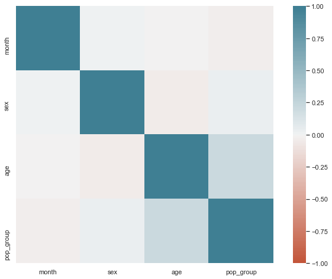

```python
corr = new_df.corr()
fig, ax = plt.subplots(figsize=(12,8))
sns.heatmap(corr, vmin=-1, vmax=1, center=0, cmap=sns.diverging_palette(20, 220, n=200), square=True, ax=ax)
```

The series of correlations together with the heatmap displays low correlation values between the selected featues ('sex','age','pop_group') and the month of death.

### *Question 2 : Does the geographical type of people influence the type of death? For example, do people in different provinces suffer from natural deaths more frequently?*

#### Province & cause

```python
contigency = pd.crosstab(df['province'], df['cause'],margins = True)
contigency
```

| cause province | natural | unknown | unnatural | All |
| --- | --- | --- | --- | --- |
| Eastern Cape | 5823 | 103 | 985 | 6911 |
| Free State | 2719 | 69 | 269 | 3057 |
| Gauteng | 5773 | 173 | 774 | 6720 |
| Kwazulu-Natal | 7912 | 186 | 1081 | 9179 |
| Limpopo | 3113 | 105 | 424 | 3642 |
| Mpumalanga | 2755 | 83 | 391 | 3229 |
| North West | 2692 | 60 | 328 | 3080 |
| Northern Cape | 891 | 15 | 111 | 1017 |
| Western Cape | 2323 | 49 | 359 | 2731 |
| All | 34001 | 843 | 4722 | 39566 |

```python
# Normalized for better visualization and understanding
contigency_norm = pd.crosstab(df['province'], df['cause'], normalize='index',margins = True)
```

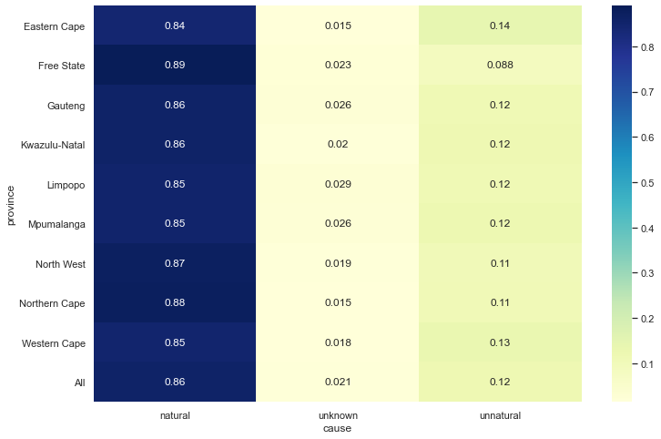

```python
plt.figure(figsize=(12,8))
sns.heatmap(contigency_norm, annot=True, cmap="YlGnBu")
```

#### Geotype & Cause

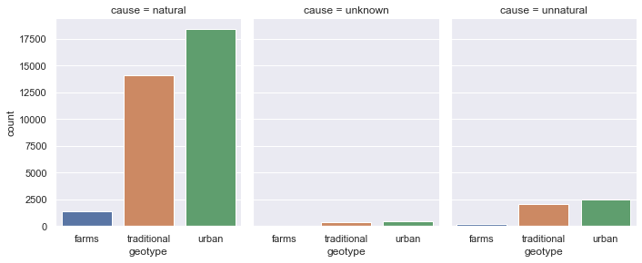

```python
g1 = sns.catplot(x="geotype", col="cause", col_wrap=4,
                data=df,
                kind="count", height=4, aspect=.8)
```

### *Question 3 : Do demographic features population group(race) and sex influence cause of death?*

**Pop_group & cause of death**

```
cause         natural  unknown  unnatural
pop_group
black           29490      769       4168
coloured         2257       42        292
indian/asian      522        4         61
other              29        1          5
white            1694       25        194
```

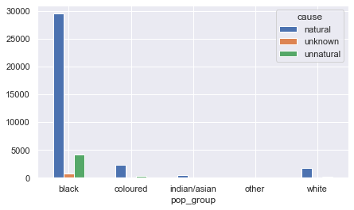

```python
CrosstabResult=pd.crosstab(index=df['pop_group'],columns=df['cause'])
print(CrosstabResult)

# Grouped bar chart between pop_group and cause
CrosstabResult.plot.bar(figsize=(7,4), rot=0)
```

**Sex & cause of death**

```
cause   natural  unknown  unnatural
sex
female    17101      411       1420
male      16788      425       3293
```

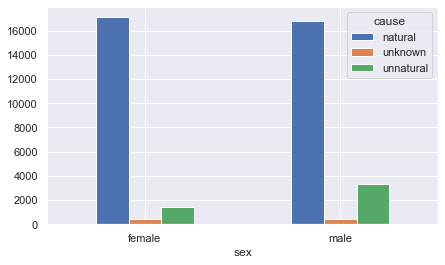

```python
CrosstabResult=pd.crosstab(index=df['sex'],columns=df['cause'])
print(CrosstabResult)

# Grouped bar chart between sex and cause
CrosstabResult.plot.bar(figsize=(7,4), rot=0)
```

From both grouped bar charts above, it is clear that the most common cause of death among the different pop_groups and genders is natural cause with unknown being least case for the cause of death.

## Model Fitting

```python
from sklearn.linear_model import LinearRegression
from sklearn.model_selection import train_test_split
from sklearn.preprocessing import OneHotEncoder
import statsmodels.api as sm
from sklearn.metrics import classification_report
```

## Question 1

Is there a relationship between age, month of death, gender and race?

The Model that we have chosen to implement for this question is a multiple linear regression model. It has been implemented via the Scikit Learn [LinearRegression](https://scikit-learn.org/stable/modules/generated/sklearn.linear_model.LinearRegression.html) class.

The features required for this model are:

- `month or month of death` (categorical)
- `sex` (categorical)
- `age` (numerical)
- `pop_group` (categorical)
- `month of death` is being predicted. The outcome is a number from 1-12 depicting the month of the year

### Data preparation so data can be fed into model

```python
infile = open('data/2011_census_mortality_clean.pkl','rb')
df = pickle.load(infile)
infile.close()

new_df = df[['month','sex', 'age','pop_group']]
new_df = new_df.dropna()

X = new_df[['age','sex','pop_group']]
y = new_df[['month']].values

#One hot encoder

enc = OneHotEncoder(handle_unknown='ignore')
X_enc = X.drop('age', axis=1)
enc.fit(X_enc)

# X_arr is a numpy array
X_arr = enc.transform(X_enc).toarray()
# add month back
X_arr = np.append(X_arr, X[['age']].to_numpy(), axis=1).astype('float')
```

### Train-Test Split

Split data randomly.

```python
X_train_orig, X_test, y_train_orig, y_test = train_test_split(X_arr, y, test_size=0.3)
X_train, X_valid, y_train, y_valid = train_test_split(X_train_orig, y_train_orig, test_size=0.3)
```

Fit model to data

```python
#fit data
from sklearn.linear_model import LinearRegression

linR = LinearRegression().fit(X_train, y_train)
```

Evaluate using validation data

```python
y_valid_pred = linR.predict(X_valid)
y_valid_pred
```

```
array([[7.03199775],
       [7.03964377],
       [6.92897937],
       ...,
       [6.93749202],
       [6.79915859],
       [7.02986959]])
```

Perform final evaluation using test data

```python
scr = linR.score(X_train, y_train)

y_pred_q1 = linR.predict(X_test)
y_test_q1 = y_test


display(y_pred_q1)

display(y_test)
```

```
array([[7.01071614],
       [6.95325578],
       [7.04815642],
       ...,
       [6.95325578],
       [6.95664547],
       [6.99794717]])
```

```
array([[ 6],
       [12],
       [11],
       ...,
       [ 3],
       [ 9],
       [10]], dtype=int64)
```

## Question 2

Does the geographical type of people influence the type of death? For example, do people in Rural or Urban areas suffer from natural deaths more frequently?

The model being used to answer this question is **multiclass logistic regression** via Scikit Learn's [LogisticRegression](https://scikit-learn.org/stable/modules/generated/sklearn.linear_model.LogisticRegression.html) class.

The features required for this model are:

- `geotype` (categorical)
- `province` (categorical)

`cause` is being predicted.

- `cause` has three possible values:
  - `natural`
  - `unnatural`
  - `unkown`

```python
q2_df = clean_df[['geotype','province','cause']].copy()
q2_df.dropna(inplace=True) # Cannot predict without data
q2_df.head()
```

| SN | geotype | province | cause |
| --- | --- | --- | --- |
| 11809257867 | farms | Western Cape | natural |
| 10104528209 | urban | Western Cape | natural |
| 10104521225 | urban | Western Cape | natural |
| 11917226239 | urban | Western Cape | natural |
| 11916914190 | urban | Western Cape | natural |

```python
q2_df['cause'].value_counts()
```

```
natural      34001
unnatural     4722
unknown        843
Name: cause, dtype: int64
```

```python
X = q2_df.drop(['cause'], axis=1)
y = q2_df['cause']
```

### Data preparation so data can be fed into model

One hot encode categorical values

```python
enc = OneHotEncoder(handle_unknown='ignore')
enc.fit(X)

# X_arr is a numpy array
X_arr = enc.transform(X).toarray()
X_arr.shape
```

```
(39566, 12)
```

Train-Validation Split

```python
X_train_orig, X_test, y_train_orig, y_test = train_test_split(X_arr, y, test_size=0.3)
X_train, X_valid, y_train, y_valid = train_test_split(X_train_orig, y_train_orig, test_size=0.3)
```

Fit model to data

```python
from sklearn.linear_model import LogisticRegression
import sklearn

log_reg = LogisticRegression().fit(X_train, y_train)
```

Evaluate using validation data

```python
y_valid_pred = log_reg.predict(X_valid)
y_valid_pred
```

```
array(['natural', 'natural', 'natural', ..., 'natural', 'natural',
       'natural'], dtype=object)
```

```python
print(classification_report(y_valid, y_valid_pred))
```

```
              precision    recall  f1-score   support

     natural       0.86      1.00      0.92      7129
     unknown       0.00      0.00      0.00       176
   unnatural       0.00      0.00      0.00      1004

    accuracy                           0.86      8309
   macro avg       0.29      0.33      0.31      8309
weighted avg       0.74      0.86      0.79      8309
```

Perform grid search to find better hyperparameters.

```python
from sklearn.model_selection import GridSearchCV

clf = LogisticRegression()
grid_values = {'solver':['sag','saga','lbfgs'], 'C':[0.001,.009,0.01,.09,1,5,10,25]}
grid_clf_acc = GridSearchCV(clf, param_grid = grid_values, scoring = 'recall_macro', verbose=2)
grid_clf_acc.fit(X_train, y_train)

y_pred_grid = grid_clf_acc.predict(X_test)

#Logistic Regression (Grid Search)
print(classification_report(y_test,y_pred_grid))
```

[output not shown]

[output cut: 75 more lines]

```
[CV] END ..................................C=25, solver=saga; total time=   0.6s
[CV] END .................................C=25, solver=lbfgs; total time=   0.2s
[CV] END .................................C=25, solver=lbfgs; total time=   0.2s
[CV] END .................................C=25, solver=lbfgs; total time=   0.2s
[CV] END .................................C=25, solver=lbfgs; total time=   0.2s
[CV] END .................................C=25, solver=lbfgs; total time=   0.2s
              precision    recall  f1-score   support

     natural       0.86      1.00      0.93     10233
     unknown       0.00      0.00      0.00       260
   unnatural       0.00      0.00      0.00      1377

    accuracy                           0.86     11870
   macro avg       0.29      0.33      0.31     11870
weighted avg       0.74      0.86      0.80     11870
```

Perform final evaluation using test data

```python
y_pred_q2 = grid_clf_acc.predict(X_test)
y_test_q2 = y_test

print(classification_report(y_test,y_pred_q2))
```

```
              precision    recall  f1-score   support

     natural       0.86      1.00      0.93     10233
     unknown       0.00      0.00      0.00       260
   unnatural       0.00      0.00      0.00      1377

    accuracy                           0.86     11870
   macro avg       0.29      0.33      0.31     11870
weighted avg       0.74      0.86      0.80     11870
```

# Question3

Do demographic features such as age or sex influence cause of death?

The model created for this Question is a Support Vector Machine. The model is implemented via Scikit Learn's [SVM](https://scikit-learn.org/stable/modules/svm.html) class.

The features required for this model are:

- `sex` (categorical)
- `age` (categorical)
- `cause` (categorical)
- `pop_group` (categorical)

`cause` is being predicted.

- `cause` has three possible values:
  - `natural`
  - `unnatural`
  - `unkown`

```python
q3_df = clean_df[['sex','age','cause','pop_group']].copy()
q3_df.dropna(inplace=True) # Cannot predict without data
q3_df.head()
```

| SN | sex | age | cause | pop_group |
| --- | --- | --- | --- | --- |
| 11809257867 | female | 0.0 | natural | coloured |
| 10104528209 | male | 85.0 | natural | coloured |
| 10104521225 | male | 72.0 | natural | coloured |
| 11917226239 | male | 73.0 | natural | coloured |
| 11916914190 | female | 46.0 | natural | indian/asian |

```python
X = q3_df.drop(['cause'], axis=1)
y = q3_df['cause']
```

### Data preparation so data can be fed into model

```python
infile = open('data/2011_census_mortality_clean.pkl','rb')
df = pickle.load(infile)
infile.close()

from sklearn.metrics import accuracy_score
from sklearn import svm

new_df = df[['sex', 'age','cause','pop_group']]
new_df = new_df.dropna()

X = new_df[['sex', 'age','pop_group']]
y = new_df[['cause']].values

enc = OneHotEncoder(handle_unknown='ignore')
X_enc = X.drop('age', axis=1)
enc.fit(X_enc)

# X_arr is a numpy array
X_arr = enc.transform(X_enc).toarray()
# add age back
X_arr = np.append(X_arr, X[['age']].to_numpy(), axis=1).astype('float')
```

Train-Validation Split

```python
X_train_orig, X_test, y_train_orig, y_test = train_test_split(X_arr, y, test_size=0.3)
X_train, X_valid, y_train, y_valid = train_test_split(X_train_orig, y_train_orig, test_size=0.3)
```

```python
#Fit svm model
svm_model = svm.SVC(kernel='rbf', gamma=0.1, C=0.1).fit(X_train, y_train)
```

Evaluate using validation data

```python
y_valid_pred = svm_model.predict(X_valid)
y_valid_pred
```

```
array(['natural', 'natural', 'natural', ..., 'natural', 'natural',
       'natural'], dtype=object)
```

```python
print(classification_report(y_valid, y_valid_pred))
```

```
              precision    recall  f1-score   support

     natural       0.87      0.99      0.92      6953
     unknown       0.00      0.00      0.00       173
   unnatural       0.53      0.09      0.15       954

    accuracy                           0.86      8080
   macro avg       0.46      0.36      0.36      8080
weighted avg       0.81      0.86      0.81      8080
```

Perform grid search to find better hyperparameters.

```python
from sklearn.svm import SVC
from sklearn.model_selection import GridSearchCV

parameters = {'C': [1, 10],'gamma': [0.001, 0.01, 1]}
model = SVC()
grid = GridSearchCV(estimator=model, param_grid=parameters)
grid.fit(X_train,y_train)
```

```
GridSearchCV(estimator=SVC(),
             param_grid={'C': [1, 10], 'gamma': [0.001, 0.01, 1]})
```

```python
print(grid)
print(grid.best_score_)
print(grid.best_estimator_)
```

```
GridSearchCV(estimator=SVC(),
             param_grid={'C': [1, 10], 'gamma': [0.001, 0.01, 1]})
0.8613939832604963
SVC(C=10, gamma=0.01)
```

```python
#Logistic Regression (Grid Search)
y_pred = grid.predict(X_test)
print(classification_report(y_test,y_pred))
```

```
              precision    recall  f1-score   support

     natural       0.87      0.98      0.93      9959
     unknown       0.00      0.00      0.00       237
   unnatural       0.51      0.13      0.21      1347

    accuracy                           0.86     11543
   macro avg       0.46      0.37      0.38     11543
weighted avg       0.81      0.86      0.82     11543
```

Perform final evaluation using test data

```python
y_pred_q3 = svm_model.predict(X_test)
y_test_q3 = y_test

svm_accuracy = accuracy_score(y_test, y_pred_q3)
print(classification_report(y_test,y_pred_q3))
```

```
              precision    recall  f1-score   support

     natural       0.87      0.99      0.93      9959
     unknown       0.00      0.00      0.00       237
   unnatural       0.50      0.09      0.15      1347

    accuracy                           0.86     11543
   macro avg       0.46      0.36      0.36     11543
weighted avg       0.81      0.86      0.82     11543
```

## Hypothesis Testing

For our hypothesis testing we have decided to use the following tests for each of our research questions:

Q1: ANOVA testing

We decided to use the ANOVA methodology for this question as it allows us to compare relationships between multiple variables.

Q2: Chi Squared

We decided to use Chi Squared testing for question 2 as it is effective in comparing the relationships between two variables. This way we can use multiple chi squared tests to check multiple different relationships.

Q3: Chi Squared

We opted to use Chi squared again for testing here as the type of testing is the same. Checking relationships between 2 variables.

### Anova

Anova is a F-distribution based test which is used to compare relationships between variables by comparing their means. It stands for, Analysis of Variance.

### Chi Squared

Chi Squared measures how a model compares to observed data. It compares discrepancies of actual data to expected results. It is generally used to compare two features to each other.

## Question 1

1. Is there a relationship between month of death to age, gender or race?

#### Null and Alternative Hypotheses

Null Hypothesis: There is no relationship between months of death and age, gender or race.

Alternative Hypothesis: There is a relationship between months of death and age, gender or race.

We have decided to use ANOVA testing to test the relationships between the variables

```python
infile = open('data/2011_census_mortality_clean.pkl','rb')
df = pickle.load(infile)
infile.close()

new_df = df[['month','sex', 'age','pop_group']]
new_df.head()

import statsmodels.api as sm
from statsmodels.formula.api import ols
model = ols('month ~ C(age) + C(pop_group) + C(sex) + C(age):C(sex):C(pop_group)', data=new_df).fit()

anova_table = sm.stats.anova_lm(model, typ=3)
display(anova_table)

row = anova_table.iloc[4]
PR = row['PR(>F)']


if PR>0.05:
    print("Reject H0, there's no relationship between variables(age,sex,pop_group) and month")

else:
    print("Retain H0, there's a relationship between variables(age,sex,pop_group) and month")
```

|  | sum_sq | df | F | PR(>F) |
| --- | --- | --- | --- | --- |
| Intercept | 68697.798575 | 1.0 | 6167.172298 | 0.000000 |
| C(age) | 1302.494012 | 115.0 | 1.016766 | 0.432521 |
| C(pop_group) | 33.968801 | 4.0 | 0.762366 | 0.549589 |
| C(sex) | 8.936062 | 1.0 | 0.802213 | 0.370438 |
| C(age):C(sex):C(pop_group) | 11167.216964 | 1039.0 | 0.964879 | 0.735224 |
| Residual | 426968.226634 | 38330.0 | NaN | NaN |

```
Reject H0, there's no relationship between variables(age,sex,pop_group) and month
```

## Question 2

1. Does the geographical type of people influence the type of death? For example, do people in Rural or Urban areas suffer from natural deaths more frequently?

#### Null and Alternative Hypotheses

Null Hypothesis: Geographical type does not influence the type of death

Alternative Hypothesis: Geographical type does influence the type of death

We have decided to implement multiple chi squared tests to test each relationship

```python
from scipy.stats import chi2_contingency

cont = pd.crosstab(q2_df.geotype, q2_df.cause, margins=True)


o_v = cont.values
b=chi2_contingency(cont)
e_v = b[3]

rows =len(cont.iloc[0:2,0])
cols =len(cont.iloc[0,0:2])
ddof=(rows-1)*(cols-1)

from scipy.stats import chi2_contingency
from scipy.stats import chi2
chi_square=sum([(o-e)**2./e for o,e in zip(o_v,e_v)])
chi_stat=chi_square[0]+chi_square[1]
c_v=chi2.ppf(df=ddof,q=1-0.05)
p_value=1-chi2.cdf(x=chi_stat,df=ddof)
print("chi statistic:",p_value)


if chi_stat>=c_v:
    print("Reject H0, there's a relationship between variables geotype and cause")

else:
    print("Retain H0, there's no relationship between variables geotype and cause")
```

```
chi statistic: 0.00019630359483713278
Reject H0, there's a relationship between variables geotype and cause
```

```python
cont = pd.crosstab(q2_df.province, q2_df.cause, margins=True)


o_v = cont.values
b=chi2_contingency(cont)
e_v = b[3]

rows =len(cont.iloc[0:2,0])
cols =len(cont.iloc[0,0:2])
ddof=(rows-1)*(cols-1)


from scipy.stats import chi2
chi_square=sum([(o-e)**2./e for o,e in zip(o_v,e_v)])
chi_stat=chi_square[0]+chi_square[1]
c_v=chi2.ppf(df=ddof,q=1-0.05)
p_value=1-chi2.cdf(x=chi_stat,df=ddof)
print("chi statistic:",p_value)


if chi_stat>=c_v:
    print("Reject H0, there's a relationship between variables province and cause")

else:
    print("Retain H0, there's no relationship between variables province and cause")
```

```
chi statistic: 3.393174630161866e-11
Reject H0, there's a relationship between variables province and cause
```

## Question 3

1. Do demographic features population group(race) and sex influence cause of death?

#### Null and Alternative Hypotheses

Null Hypothesis: Demographic features population group and sex do not influence cause of death

Alternative Hypothesis: Demographic features population group and sex do influence cause of death

We have decided to implent multiple chi-squared tests here to test each relationship seperately

```python
infile = open('data/2011_census_mortality_clean.pkl','rb')
df = pickle.load(infile)
infile.close()

from scipy.stats import chi2_contingency

new_df = df[['sex', 'age','cause','pop_group']]
new_df = new_df.replace(['natural', 'unknown', 'unnatural'],[0,1,2])
new_df = new_df.replace(['male', 'female'],[0,1])
new_df = new_df.replace(['black', 'coloured', 'indian/asian', 'other', 'white'],[0,1,2,3,4])
new_df = new_df.dropna()

new_df.head()


cont = pd.crosstab(new_df.sex, new_df.cause, margins=True)


o_v = cont.values
b=chi2_contingency(cont)
e_v = b[3]

rows =len(cont.iloc[0:2,0])
cols =len(cont.iloc[0,0:2])
ddof=(rows-1)*(cols-1)


from scipy.stats import chi2
chi_square=sum([(o-e)**2./e for o,e in zip(o_v,e_v)])
chi_stat=chi_square[0]+chi_square[1]
c_v=chi2.ppf(df=ddof,q=1-0.05)
p_value=1-chi2.cdf(x=chi_stat,df=ddof)
print("chi statistic:",chi_stat)


if chi_stat>=c_v:
    print("Reject H0, there's a relationship between variables sex and cause")

else:
    print("Retain H0, there's no relationship between variables sex and cause")
```

```
chi statistic: 80.39797724321191
Reject H0, there's a relationship between variables sex and cause
```

```python
cont = pd.crosstab(new_df.pop_group, new_df.cause, margins=True)


o_v = cont.values
b=chi2_contingency(cont)
e_v = b[3]

rows =len(cont.iloc[0:2,0])
cols =len(cont.iloc[0,0:2])
ddof=(rows-1)*(cols-1)


from scipy.stats import chi2
chi_square=sum([(o-e)**2./e for o,e in zip(o_v,e_v)])
chi_stat=chi_square[0]+chi_square[1]
c_v=chi2.ppf(df=ddof,q=1-0.05)
p_value=1-chi2.cdf(x=chi_stat,df=ddof)
print("chi statistic:",chi_stat)


if chi_stat>=c_v:
    print("Reject H0, there's a relationship between variables pop_group and cause")

else:
    print("Retain H0, there's no relationship between variables pop_group and cause")
```

```
chi statistic: 21.798607571981716
Reject H0, there's a relationship between variables pop_group and cause
```

## Interpreting Results

### Analysis of Models

```python
# Imports
from sklearn.metrics import classification_report, mean_squared_error as mse, mean_absolute_error as mae, confusion_matrix
```

The classification metrics **precision**, **recall** and **F1 score** are used. Their formulas are given below.

**Precision** $= \frac{\text{#True Postives}}{\text{#True Postives} + \text{#False Postives}}$  
I.e. the percentage of positive predictions which were predicted correctly.

**Recall** $= \frac{\text{#True Postives}}{\text{#True Postives} + \text{#False Negatives}}$  
I.e. the percentage of positive labels which were predicted correctly.

**F1 Score** $= 2 \times \frac{\text{Precision} \times \text{Recall}}{\text{Precision} + \text{Recall}}$  
I.e. the harmonic mean of precision and recall.

#### Question 1

```python
print(f"Mean Squared Error: {mse(y_test_q1, y_pred_q1)}")
print(f"Mean Absolute Error: {mae(y_test_q1, y_pred_q1)}")
```

```
Mean Squared Error: 11.094317118537687
Mean Absolute Error: 2.8702941216449838
```

From the mean absolute error we can see that on average the predicted month varies by ~3 months from the actual month. This indicates poor performance of the model.

#### Question 2

```python
conf_mat = confusion_matrix(y_test_q2, y_pred_q2)
conf_mat_pd = pd.DataFrame(conf_mat, columns = ["natural", "unkown", "unnatural"], index=["natural", "unkown", "unnatural"])
conf_mat_pd
```

|  | natural | unkown | unnatural |
| --- | --- | --- | --- |
| natural | 10233 | 0 | 0 |
| unkown | 260 | 0 | 0 |
| unnatural | 1377 | 0 | 0 |

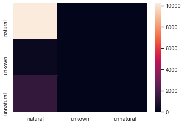

```python
sns.heatmap(conf_mat_pd)
```

From the above we can see that the model predicted all the test data as having a 'natural' cause of death. We can also see that there is dispraportionally more 'natural' deaths than 'unnatural' or 'unkown' which helps explain why the model is biased towards only predicting 'natural'.

```python
print(f"{classification_report(y_test_q2, y_pred_q2)}")
```

```
              precision    recall  f1-score   support

     natural       0.86      1.00      0.93     10233
     unknown       0.00      0.00      0.00       260
   unnatural       0.00      0.00      0.00      1377

    accuracy                           0.86     11870
   macro avg       0.29      0.33      0.31     11870
weighted avg       0.74      0.86      0.80     11870
```

This model performs very poorly as it simply predicts all deaths as being 'natural'. By predicting all deaths as being 'natural' the model has a high total accuracy but this is simply because the data is biased and the majority of the deaths are 'natural'. Looking at the 'macro average' of the metrics precision, recall and f1-score we see a better indication of the perfromance of the model. The macro average of a metric is the (unweighted) average of that metric for each predicted label. I.e. in the case of the macro average of precision it would be $(0.86+0.00+0.00)/3 = 0.29$. The macro averages for precision, recall and f1-score are 0.29, 0.33 and 0.31 respectively. These numbers indicate very poor performance of the model for predicting all labels correctly rather than predicting 'natural' correctly.

#### Question 3

```python
conf_mat = confusion_matrix(y_test_q3, y_pred_q3)
conf_mat_pd = pd.DataFrame(conf_mat, columns = ["natural", "unkown", "unnatural"], index=["natural", "unkown", "unnatural"])
conf_mat_pd
```

|  | natural | unkown | unnatural |
| --- | --- | --- | --- |
| natural | 9845 | 0 | 114 |
| unkown | 233 | 0 | 4 |
| unnatural | 1228 | 0 | 119 |

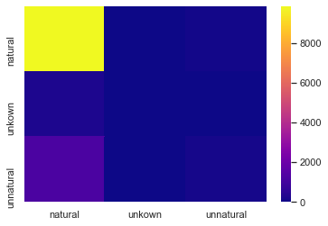

```python
sns.heatmap(conf_mat_pd, cmap="plasma")
```

From the above we can see that the model predicted most of the test data as having a 'natural' cause of death. We can also see that there is dispraportionally more 'natural' deaths than 'unnatural' or 'unkown' which helps explain why the model is biased towards dispraportionally predicting 'natural'.

```python
print(f"{classification_report(y_test_q3, y_pred_q3)}")
```

```
              precision    recall  f1-score   support

     natural       0.87      0.99      0.93      9959
     unknown       0.00      0.00      0.00       237
   unnatural       0.50      0.09      0.15      1347

    accuracy                           0.86     11543
   macro avg       0.46      0.36      0.36     11543
weighted avg       0.81      0.86      0.82     11543
```

### Analysis of Hypothesis Tests

#### Question 1

Is there a relationship between month of death to age, gender or race?

Null Hypothesis: There is no relationship between months of death and age, gender or race.

Alternative Hypothesis: There is a relationship between months of death and age, gender or race.

If we analyze the results of the anova table we can see that for all of our variables we get P value scores of above 0.05 for all of the possible combinations. This means that we do not have a relationship between variables and we do not reject our null hypothesis. Thus we can conclude that there is no relationship between months of death to age, gender or race.

Looking at these results, this conclusion might seem obvious at first, but for us we found the results to be a bit different to what we expected. Based on the demographics of South African society and issues related to poverty and living conditions, we expected to have a spike in deaths around the winter months. We originally thought that whis would reflect in both race and age, but our initial expectations proved to be false.

#### Question 2

Does the geographical type of people influence the type of death? For example, do people in Rural or Urban areas suffer from natural deaths more frequently?

Null Hypothesis: Geographical type does not influence the type of death

Alternative Hypothesis: Geographical type does influence the type of death

These results meet our expectations as we did expect geographical type to have some influence on types of deaths. For geographical types, people living in Rural areas tend to have less access to advanced medical care that people in Urban areas would have access to. Similarly, people in urban areas are more prone to deaths in things such as motor vehicle accidents compared to rural areas where vehicles are rarer. As far as provinces go, again certain provinces have access to better medical facilities. Comparing Gauteng and Limpopo province for example would provide a stark contrast in medical care.

#### Question 3

Do demographic features population group(race) and sex influence cause of death?

Null Hypothesis: Demographic features population group and sex do not influence cause of death

Alternative Hypothesis: Demographic features population group and sex do influence cause of death

If we analyze the results given by our chi-squared tests, we get the following results: For the relationship between sex and cause of death we got a chi squared value of 80.39797724321191 For the relationship between pop_group and cause of death we got a chi squared value of 21.798607571981716

Again both of these values are above our chosen significance level so we can say there is a relationship between the variables here. We reject our null hypothesis.

These results meet the expectations we had for this research question. For Sex and cause of death, it is well known that different genders are prone to different ailments. Men for example are more prone to cholesterol related diseases such as heart attacks compared to women. Similarly things such as breast cancer are a lot more prevalent in women than men. As for pop_group it is also well known that different races have different ailments. In South Africa, Indian men and Afrikaans white men tend to suffer from higher cholestrol. Conversely Black men and women have much lower incidences of skin cancer. These results mirror those results and is reflected here in our hypothesis tests.

## Conclusions

Based on our models and hypothesis testing we now have the ability to answer our research questions:

#### Question 1

Is there a relationship between month of death to age, gender or race?

We can say there is no relationship between the month of death to age, gender or race. There is no evidence here of certain months in the year having more deaths of certain ages, genders or races.

#### Question 2

Does the geographical type of people influence the type of death? For example, do people in Rural or Urban areas suffer from natural deaths more frequently?

We can say that the geographical type of people does influence the type of death. People in Urban and Rural areas suffer from different deaths, specifically unnatural and natural. This extends to people in different provinces suffering from different types of deaths. This could also be related to certain provinces having more people living in rural areas compared to urban areas.

#### Question 3

Do demographic features population group(race) and sex influence cause of death?

We can say that the demographic features of race and sex do influence the cause of death. This tells us that different genders do suffer from different causes of death. Furthermore, different races also suffer from different causes of death.

### Further Research

In order to progress our research further we could improve on certain things:

We would like to use the entire dataset instead of a 10% sample to see if our results would differ, particularly in the model fitting section. This would require getting access to the entire dataset as well as a computer which is a lot more powerful and has the potential to process such a large dataset. This would likely solve the issues we have seen in our model fitting where our model was predicting only natural deaths.

Another thing we would like to add is to extend our data set by adding additional features onto the dataset. This would allow us to test for multiple other relationships between variables.

Finally another way we could refine our results is to use multiple different hypothesis tests on each research question instead of the single tests we have implemented now. For example T-Tests and Z-tests.